# Create your first cross-platform app

Here you will learn how to create and run your first Kotlin Multiplatform application using Android Studio.

## Create the project from a template

1. In Android Studio, select **File | New | New Project**.
2. Select **Kotlin Multiplatform App** in the list of project templates, and click **Next**.

[figure not shown]

3. Specify a name for your first application, and click **Next**.

[figure not shown]

4. In the **iOS framework distribution** list, select the **Regular framework** option.

[figure not shown]

5. Keep the default names for the application and shared folders. Click **Finish**.

The project will be set up automatically. It may take some time to download and set up the required components when you do this for the first time.

## Examine the project structure

To view the full structure of your mobile multiplatform project, switch the view from **Android** to **Project**.

[figure not shown]

Each Kotlin Multiplatform project includes three modules:

- *shared* is a Kotlin module that contains the logic common for both Android and iOS applications – the code you share between platforms. It uses Gradle as the build system that helps you automate your build process. The *shared* module builds into an Android library and an iOS framework.
- *androidApp* is a Kotlin module that builds into an Android application. It uses Gradle as the build system. The *androidApp* module depends on and uses the shared module as a regular Android library.
- *iosApp* is an Xcode project that builds into an iOS application. It depends on and uses the shared module as an iOS framework. The shared module can be used as a regular framework or as a CocoaPods dependency, based on what you've chosen in the previous step in **iOS framework distribution**. In this tutorial, it's a regular framework dependency.

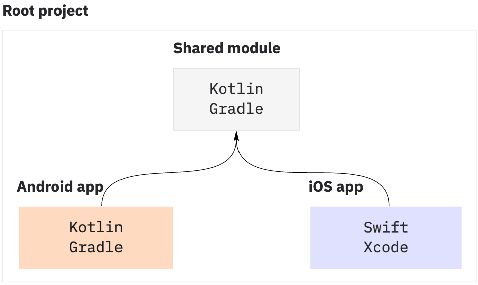

The shared module consists of three source sets: `androidMain`, `commonMain`, and `iosMain`. *Source set* is a Gradle concept for a number of files logically grouped together where each group has its own dependencies. In Kotlin Multiplatform, different source sets in a shared module can target different platforms.

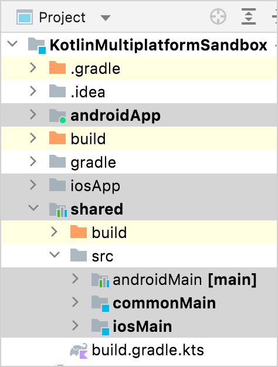

## Run your application

You can run your multiplatform application on Android or iOS.

### Run your application on Android

1. Create an [Android virtual device](https://developer.android.com/studio/run/managing-avds#createavd).
2. In the list of run configurations, select **androidApp**.
3. Choose your Android virtual device and click **Run**.

[figure not shown]

[figure not shown]

#### Run on a different Android simulated device

Learn how to [configure the Android Emulator and run your application on a different simulated device](https://developer.android.com/studio/run/emulator#runningapp).

#### Run on a real Android device

Learn how to [configure and connect a hardware device and run your application on it](https://developer.android.com/studio/run/device).

### Run your application on iOS

1. Launch Xcode in a separate window. The first time you may also need to accept its license terms and allow it to perform some necessary initial tasks.
2. In Android Studio, select **iosApp** in the list of run configurations and click **Run**.

   If you don't have an available iOS configuration in the list, add a new iOS simulated device.

[figure not shown]

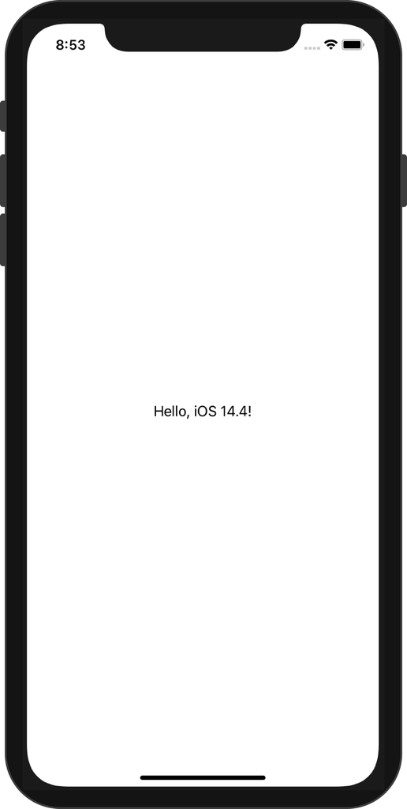

#### Run on a new iOS simulated device

If you want to run your application on a simulated device, you can add a new run configuration.

1. In the list of run configurations, click **Edit Configurations**.

[figure not shown]

2. Click the **+** button above the list of configurations and select **iOS Application**.

[figure not shown]

3. Name your configuration.
4. Select the **Xcode project file**. For that, navigate to your project, for example **KotlinMultiplatformSandbox**, open the`iosApp` folder and select the `.xcodeproj` file.
5. In the **Execution target** list, select a simulated device and click **OK**.

[figure not shown]

6. Click **Run** to run your application on the new simulated device.

#### Run on a real iOS device

1. Connect a real iPhone device to Xcode.
2. Make sure to code sign your app. For more information, see the [official Apple documentation](https://developer.apple.com/documentation/xcode/running-your-app-in-simulator-or-on-a-device/).
3. Create a run configuration by selecting an iPhone in the **Execution target** list.
4. Click **Run** to run your application on the iPhone device.

## Update your application

1. In `shared/src/commonMain/kotlin`, open the `Greeting.kt` file in the project folder. This directory stores the shared code for both Android and iOS. If you make changes to the shared code, you will see them reflected in both applications.

[figure not shown]

2. Update the shared code by using `reversed()`, the Kotlin standard library function for reversing text that works on all platforms:

3. Re-run the **androidApp** configuration to see the updated application in the Android simulated device.

[figure not shown]

4. In Android Studio, switch to **iosApp** and re-run it to see the updated application in the iOS simulated device.

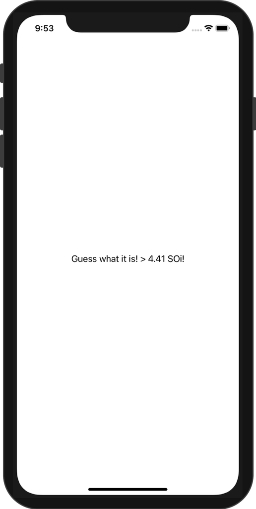

## Next step

In the next part of the tutorial, you'll learn about dependencies and add a third-party library to expand the functionality of your project.

**Proceed to the next part**

### See also

- See how to create and run multiplatform tests to check that the code works correctly.
- Learn more about the project structure, the shared module's artifacts, and how the Android and iOS apps are produced.

## Get help

- **Kotlin Slack**. Get an [invite](https://surveys.jetbrains.com/s3/kotlin-slack-sign-up) and join the [#multiplatform](https://kotlinlang.slack.com/archives/C3PQML5NU) channel.
- **Kotlin issue tracker**. [Report a new issue](https://youtrack.jetbrains.com/newIssue?project=KT).

Last modified: 11 April 2023